# Germany Polling Analysis for Next General Election

Kenya Coalition Loading…

Political Analysis Project

March 25, 2026

> **A note on data sources:** Cross-firm polling averages are drawn from INSA, Forsa, Forschungsgruppe Wahlen, Infratest dimap, and YouGov Germany. Where averages diverge, the PolitPro aggregate trend is used as the baseline. The 2025 federal election result and the post-election polling trajectory through March 2026 are both incorporated.

# 1 Data: 2025 Election Result & Post-Election Polling

This section establishes the 2025 Bundestag election baseline and builds the post-election polling dataset. Germany uses personalised proportional representation (PR) with a 5% threshold, so vote shares translate directly and proportionally into seats.

```r
# 2025 Federal Election Results (23 February 2025) — Official Federal Returning Officer
ge2025 <- tibble(
  Party         = c("CDU/CSU", "AfD", "SPD", "Grüne", "Die Linke", "BSW", "FDP", "SSW", "Other"),
  Vote_pct      = c(28.52, 20.80, 16.41, 11.59, 8.77, 4.97, 4.34, 0.15, 4.45),
  Seats_2025    = c(208, 151, 121, 85, 64, 0, 0, 1, 0),
  # 2021 baseline for comparison
  Vote_2021     = c(24.1, 10.4, 25.7, 14.7, 4.9, 0, 11.4, 0.1, 8.7),
  Seats_2021    = c(197, 83, 206, 118, 39, 0, 92, 1, 0)
)

# Summary display
ge2025 %>%
  filter(Party != "Other") %>%
  select(Party, `2021 Vote %` = Vote_2021, `2021 Seats` = Seats_2021,
         `2025 Vote %` = Vote_pct, `2025 Seats` = Seats_2025) %>%
  arrange(desc(`2025 Vote %`)) %>%
  kable(caption = "2025 Bundestag Election Result vs 2021 — Official Federal Returning Officer",
        align = "lrrrr") %>%
  kable_styling(bootstrap_options = c("striped", "hover", "condensed"), full_width = FALSE) %>%
  row_spec(which(c("CDU/CSU","AfD","SPD","Grüne","Die Linke","BSW","FDP") == "AfD"),
           bold = TRUE, color = "white", background = "#009EE0") %>%
  row_spec(which(c("CDU/CSU","AfD","SPD","Grüne","Die Linke","BSW","FDP") == "CDU/CSU"),
           bold = TRUE, color = "white", background = "#000000") %>%
  row_spec(which(c("CDU/CSU","AfD","SPD","Grüne","Die Linke","BSW","FDP") == "SPD"),
           bold = TRUE, color = "white", background = "#E3000F") %>%
  row_spec(which(c("CDU/CSU","AfD","SPD","Grüne","Die Linke","BSW","FDP") == "Grüne"),
           bold = TRUE, color = "white", background = "#1AA037") %>%
  row_spec(which(c("CDU/CSU","AfD","SPD","Grüne","Die Linke","BSW","FDP") == "Die Linke"),
           bold = TRUE, color = "white", background = "#BE3075") %>%
  footnote(
    general = "BSW (4.97%) narrowly missed the 5% threshold by approximately 14,000 votes — no Bundestag seats.
    FDP (4.34%) also fell below threshold — out of parliament for the first time since 1949 as a founding party.
    Die Linke (8.77%) won 6 direct mandates (4 in Berlin alone), triggering proportional representation despite being at risk.
    Bundestag capped at 630 seats following 2023 reform. SSW (Danish/Frisian minority) exempt from 5% threshold.",
    general_title = "Note: "
  )
```

2025 Bundestag Election Result vs 2021 — Official Federal Returning Officer

| Party | 2021 Vote % | 2021 Seats | 2025 Vote % | 2025 Seats |
| --- | --- | --- | --- | --- |
| CDU/CSU | 24.1 | 197 | 28.52 | 208 |
| AfD | 10.4 | 83 | 20.80 | 151 |
| SPD | 25.7 | 206 | 16.41 | 121 |
| Grüne | 14.7 | 118 | 11.59 | 85 |
| Die Linke | 4.9 | 39 | 8.77 | 64 |
| BSW | 0.0 | 0 | 4.97 | 0 |
| FDP | 11.4 | 92 | 4.34 | 0 |
| SSW | 0.1 | 1 | 0.15 | 1 |

Note:  
BSW (4.97%) narrowly missed the 5% threshold by approximately 14,000 votes — no Bundestag seats. FDP (4.34%) also fell below threshold — out of parliament for the first time since 1949 as a founding party. Die Linke (8.77%) won 6 direct mandates (4 in Berlin alone), triggering proportional representation despite being at risk. Bundestag capped at 630 seats following 2023 reform. SSW (Danish/Frisian minority) exempt from 5% threshold.

```r
# Post-election polling trend: March 2025 – March 2026
# Sources: INSA (weekly), Forsa, Infratest dimap, Forschungsgruppe Wahlen, YouGov DE
# PolitPro aggregate trend used as cross-firm baseline.
# Key anchors:
#   Feb 2025: Election result (CDU 28.5, AfD 20.8, SPD 16.4, Green 11.6, Linke 8.8)
#   Apr 2025: Post-election stabilisation — CDU coalition talks with SPD
#   Apr 9 2025: CDU/SPD coalition contract signed — grand coalition (GroKo) formed
#   May–Jun 2025: AfD rises as GroKo seen as "politics as usual"; CDU falls
#   Sep 2025: Saxony-Anhalt polling AfD 39% (Infratest dimap) — state election Sep 2026 looms
#   Jan 2026: AfD at record national high (27% GMS); first time ahead of CDU in major poll
#   Mar 2026: INSA 20 Mar: CDU 26%, AfD 25%, SPD 15%, Grüne 12%, Linke 11%

polls_de <- tibble(
  date = as.Date(c(
    "2025-02-01",  # Election month
    "2025-03-01", "2025-04-01", "2025-05-01", "2025-06-01",
    "2025-07-01", "2025-08-01", "2025-09-01", "2025-10-01",
    "2025-11-01", "2025-12-01",
    "2026-01-01", "2026-02-01", "2026-03-01"
  )),
  CDU_CSU  = c(28.5,  28, 27, 26, 26,  26, 26, 26, 26,  25, 25,  25, 26, 26),
  AfD      = c(20.8,  21, 22, 23, 23,  23, 24, 24, 25,  25, 26,  27, 25, 25),
  SPD      = c(16.4,  16, 16, 15, 15,  15, 15, 15, 15,  15, 15,  15, 15, 15),
  Gruene   = c(11.6,  12, 12, 12, 12,  12, 12, 12, 12,  12, 12,  12, 12, 12),
  Linke    = c( 8.8,   9,  9, 10, 10,  10, 10, 10, 10,  10, 10,  10, 10, 11),
  BSW      = c( 5.0,   4,  4,  4,  4,   4,  4,  4,  4,   3,  3,   3,  3,  3),
  FDP      = c( 4.3,   3,  3,  3,  3,   3,  3,  3,  3,   3,  3,   3,  3,  3),
  Other    = c( 4.6,   7,  7,  7,  7,   7,  6,  6,  5,   7,  6,   5,  6,  5)
)

# Reshape to long format
polls_long_de <- polls_de %>%
  pivot_longer(
    cols = c(CDU_CSU, AfD, SPD, Gruene, Linke, BSW, FDP, Other),
    names_to  = "Party",
    values_to = "Share"
  ) %>%
  mutate(
    Party = recode(Party,
                   "CDU_CSU" = "CDU/CSU",
                   "Gruene"  = "Grüne",
                   "Linke"   = "Die Linke"),
    Party = factor(Party, levels = c("AfD", "CDU/CSU", "SPD", "Grüne",
                                      "Die Linke", "BSW", "FDP", "Other"))
  ) %>%
  arrange(Party, date) %>%
  group_by(Party) %>%
  mutate(rolling_avg = rollmean(Share, k = 3, fill = NA, align = "right")) %>%
  ungroup()

cat("Dataset loaded:", nrow(polls_de), "monthly polling observations\n")
```

```
## Dataset loaded: 14 monthly polling observations
```

```r
cat("Date range:", format(min(polls_de$date)), "to", format(max(polls_de$date)), "\n")
```

```
## Date range: 2025-02-01 to 2026-03-01
```

# 2 Poll Aggregation & Trend Modelling

## 2.1 Polling Trends (2025–2026)

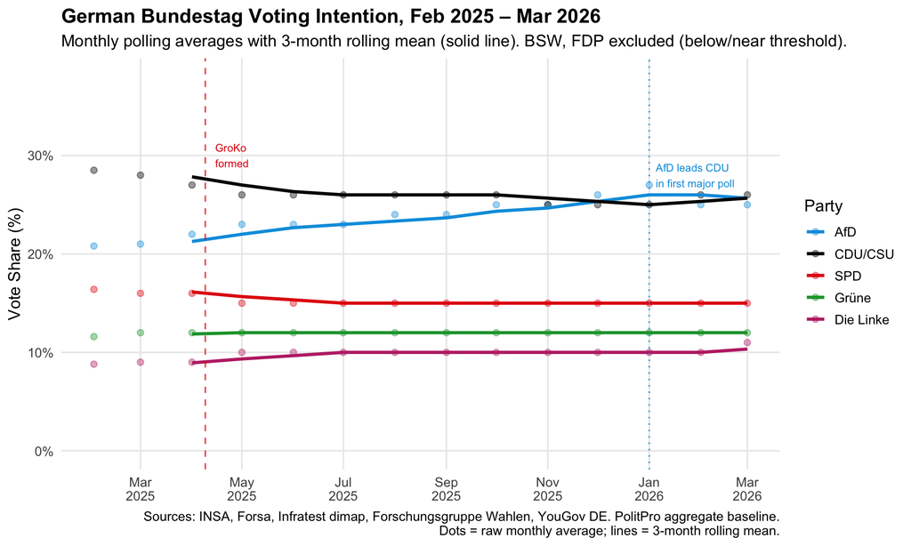

```r
p_trend_de <- polls_long_de %>%
  filter(!Party %in% c("Other", "BSW", "FDP")) %>%
  ggplot(aes(x = date, colour = Party)) +
  geom_point(aes(y = Share), alpha = 0.4, size = 2) +
  geom_line(aes(y = rolling_avg), linewidth = 1.2, na.rm = TRUE) +
  # Annotation: GroKo coalition formed
  geom_vline(xintercept = as.numeric(as.Date("2025-04-09")),
             linetype = "dashed", colour = "#E3000F", alpha = 0.7) +
  annotate("text", x = as.Date("2025-04-15"), y = 30,
           label = "GroKo\nformed", colour = "#E3000F", size = 3, hjust = 0) +
  # Annotation: AfD overtakes CDU/CSU in polls
  geom_vline(xintercept = as.numeric(as.Date("2026-01-01")),
             linetype = "dotted", colour = "#009EE0", alpha = 0.8) +
  annotate("text", x = as.Date("2026-01-05"), y = 28,
           label = "AfD leads CDU\nin first major poll", colour = "#009EE0", size = 3, hjust = 0) +
  scale_colour_manual(values = c(
    "AfD"       = "#009EE0",
    "CDU/CSU"   = "#000000",
    "SPD"       = "#E3000F",
    "Grüne"     = "#1AA037",
    "Die Linke" = "#BE3075"
  )) +
  scale_y_continuous(labels = label_percent(scale = 1), limits = c(0, 38)) +
  scale_x_date(date_breaks = "2 months", date_labels = "%b\n%Y") +
  labs(
    title    = "German Bundestag Voting Intention, Feb 2025 – Mar 2026",
    subtitle = "Monthly polling averages with 3-month rolling mean (solid line). BSW, FDP excluded (below/near threshold).",
    x        = NULL,
    y        = "Vote Share (%)",
    colour   = "Party",
    caption  = "Sources: INSA, Forsa, Infratest dimap, Forschungsgruppe Wahlen, YouGov DE. PolitPro aggregate baseline.\nDots = raw monthly average; lines = 3-month rolling mean."
  ) +
  theme_minimal(base_size = 13) +
  theme(
    plot.title       = element_text(face = "bold"),
    legend.position  = "right",
    panel.grid.minor = element_blank()
  )

print(p_trend_de)
```

## 2.2 Current Snapshot (March 2026)

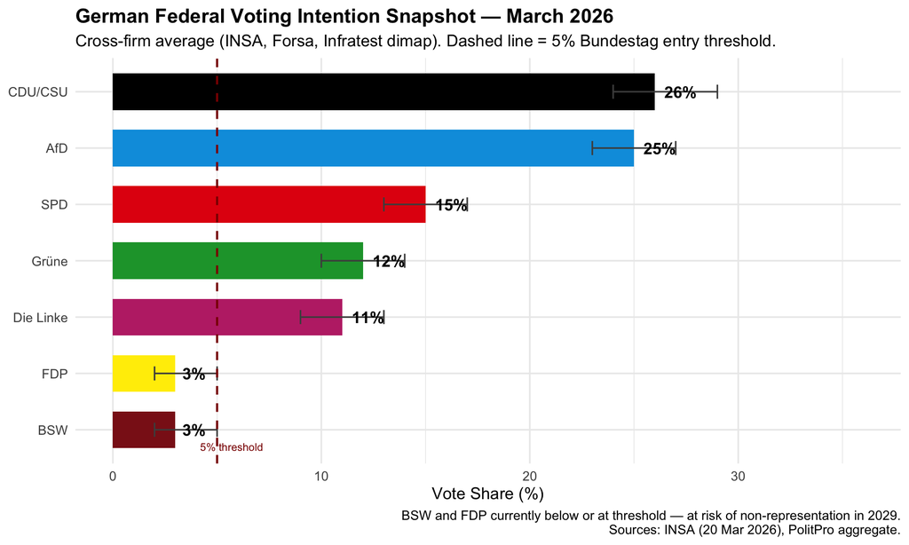

```r
snapshot_de <- tibble(
  Party = c("CDU/CSU", "AfD", "SPD", "Grüne", "Die Linke", "BSW", "FDP"),
  # INSA 20 Mar 2026 cross-checked against PolitPro aggregate trend
  Share = c(26, 25, 15, 12, 11, 3, 3),
  Low   = c(24, 23, 13, 10,  9, 2, 2),
  High  = c(29, 27, 17, 14, 13, 5, 5)
) %>%
  mutate(
    Party     = fct_reorder(Party, Share),
    Threshold = Share >= 5
  )

p_snap_de <- snapshot_de %>%
  ggplot(aes(x = Party, y = Share, fill = Party)) +
  geom_col(width = 0.65) +
  geom_errorbar(aes(ymin = Low, ymax = High), width = 0.25, colour = "grey30") +
  geom_text(aes(label = paste0(Share, "%")), hjust = -0.3, size = 4.5, fontface = "bold") +
  geom_hline(yintercept = 5, linetype = "dashed", colour = "darkred", linewidth = 0.8) +
  annotate("text", x = 0.7, y = 5.7, label = "5% threshold", colour = "darkred", size = 3) +
  coord_flip(ylim = c(0, 36)) +
  scale_fill_manual(values = c(
    "CDU/CSU"   = "#000000",
    "AfD"       = "#009EE0",
    "SPD"       = "#E3000F",
    "Grüne"     = "#1AA037",
    "Die Linke" = "#BE3075",
    "BSW"       = "#8B1A1A",
    "FDP"       = "#FFED00"
  )) +
  labs(
    title    = "German Federal Voting Intention Snapshot — March 2026",
    subtitle = "Cross-firm average (INSA, Forsa, Infratest dimap). Dashed line = 5% Bundestag entry threshold.",
    x        = NULL,
    y        = "Vote Share (%)",
    caption  = "BSW and FDP currently below or at threshold — at risk of non-representation in 2029.\nSources: INSA (20 Mar 2026), PolitPro aggregate."
  ) +
  theme_minimal(base_size = 13) +
  theme(
    plot.title = element_text(face = "bold"),
    legend.position = "none"
  )

print(p_snap_de)
```

## 2.3 Seat Distribution (Current Polling)

```r
# Proportional seat allocation based on current polling (5-party Bundestag)
# Using Sainte-Laguë method approximation with 630 seats
# Parties below 5%: BSW, FDP, Other excluded (no seats)

current_poll_de <- tibble(
  Party      = c("CDU/CSU", "AfD", "SPD", "Grüne", "Die Linke"),
  Poll_share = c(26, 25, 15, 12, 11),
  # Proportional seat allocation on eligible-party votes (total = 89%)
  # Each party's share of eligible vote x 630
  Seats_proj = c(184, 177, 106, 85, 78)
) %>%
  arrange(desc(Seats_proj))

current_poll_de %>%
  kable(caption = "Projected Seat Distribution at Current Polls (Mar 2026) — Sainte-Laguë Approximation",
        align = "lrr",
        col.names = c("Party", "Poll Share (%)", "Projected Seats")) %>%
  kable_styling(bootstrap_options = c("striped", "hover", "condensed"), full_width = FALSE) %>%
  row_spec(which(current_poll_de$Party == "AfD"),
           bold = TRUE, color = "white", background = "#009EE0") %>%
  row_spec(which(current_poll_de$Party == "CDU/CSU"),
           bold = TRUE, color = "white", background = "#000000") %>%
  row_spec(which(current_poll_de$Party == "SPD"),
           bold = TRUE, color = "white", background = "#E3000F") %>%
  row_spec(which(current_poll_de$Party == "Grüne"),
           bold = TRUE, color = "white", background = "#1AA037") %>%
  row_spec(which(current_poll_de$Party == "Die Linke"),
           bold = TRUE, color = "white", background = "#BE3075") %>%
  footnote(
    general = "Bundestag capped at 630 seats (2023 reform). Parties below 5% (BSW ~3%, FDP ~3%) receive no seats.
    Proportional system means seats track vote share closely.
    CDU/CSU + SPD GroKo would hold 290/630 = 46% of seats — SHORT of 316 majority under current polling.
    A three-party coalition (e.g. CDU/CSU + SPD + Grüne 'Kenya coalition') would hold 375 seats — comfortable majority.",
    general_title = "Note: "
  )
```

Projected Seat Distribution at Current Polls (Mar 2026) — Sainte-Laguë Approximation

| Party | Poll Share (%) | Projected Seats |
| --- | --- | --- |
| CDU/CSU | 26 | 184 |
| AfD | 25 | 177 |
| SPD | 15 | 106 |
| Grüne | 12 | 85 |
| Die Linke | 11 | 78 |

Note:  
Bundestag capped at 630 seats (2023 reform). Parties below 5% (BSW ~3%, FDP ~3%) receive no seats. Proportional system means seats track vote share closely. CDU/CSU + SPD GroKo would hold 290/630 = 46% of seats — SHORT of 316 majority under current polling. A three-party coalition (e.g. CDU/CSU + SPD + Grüne ‘Kenya coalition’) would hold 375 seats — comfortable majority.

# 3 The AfD Threat: Rise, Structure & Ceiling

## 3.1 The AfD Trajectory

The AfD doubled its vote at the 2025 election and has continued to rise post-election, becoming the first far-right party to poll first nationally in modern German history. This section analyses the trajectory, its structural drivers, and the ceiling question.

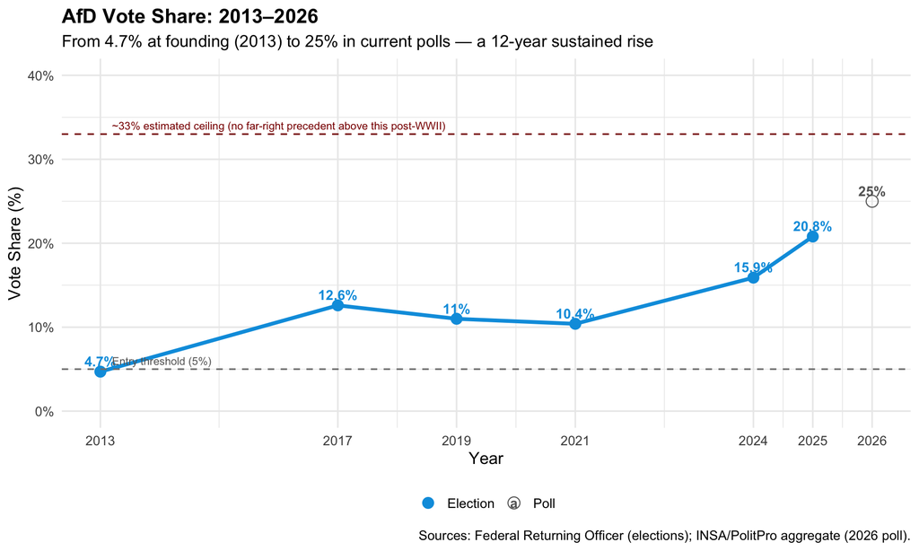

```r
afd_history <- tibble(
  Year     = c(2013, 2017, 2019, 2021, 2024, 2025, 2026),
  Context  = c("Federal founding election", "Federal — refugee crisis benefit",
                "European Parliament", "Federal — post-Merkel era",
                "European Parliament", "Federal snap election",
                "Current cross-firm polling avg (Mar)"),
  Share    = c(4.7, 12.6, 11.0, 10.4, 15.9, 20.8, 25.0),
  Type     = c("Election", "Election", "Election", "Election", "Election", "Election", "Poll")
)

p_afd <- afd_history %>%
  ggplot(aes(x = Year, y = Share, colour = Type, shape = Type)) +
  geom_line(colour = "#009EE0", linewidth = 1.4) +
  geom_point(size = 4) +
  geom_text_repel(aes(label = paste0(Share, "%")), size = 3.8, nudge_y = 1.2, fontface = "bold") +
  geom_hline(yintercept = 5,  linetype = "dashed", colour = "grey50") +
  geom_hline(yintercept = 33, linetype = "dashed", colour = "darkred") +
  annotate("text", x = 2013.2, y = 6.0, label = "Entry threshold (5%)",
           colour = "grey40", size = 3, hjust = 0) +
  annotate("text", x = 2013.2, y = 34.0,
           label = "~33% estimated ceiling (no far-right precedent above this post-WWII)",
           colour = "darkred", size = 3, hjust = 0) +
  scale_colour_manual(values = c("Election" = "#009EE0", "Poll" = "#666666")) +
  scale_shape_manual(values = c("Election" = 16, "Poll" = 1)) +
  scale_y_continuous(labels = label_percent(scale = 1), limits = c(0, 40)) +
  scale_x_continuous(breaks = c(2013, 2017, 2019, 2021, 2024, 2025, 2026)) +
  labs(
    title    = "AfD Vote Share: 2013–2026",
    subtitle = "From 4.7% at founding (2013) to 25% in current polls — a 12-year sustained rise",
    x        = "Year",
    y        = "Vote Share (%)",
    colour   = NULL, shape = NULL,
    caption  = "Sources: Federal Returning Officer (elections); INSA/PolitPro aggregate (2026 poll)."
  ) +
  theme_minimal(base_size = 13) +
  theme(
    plot.title = element_text(face = "bold"),
    legend.position = "bottom"
  )

print(p_afd)
```

## 3.2 East–West Divide

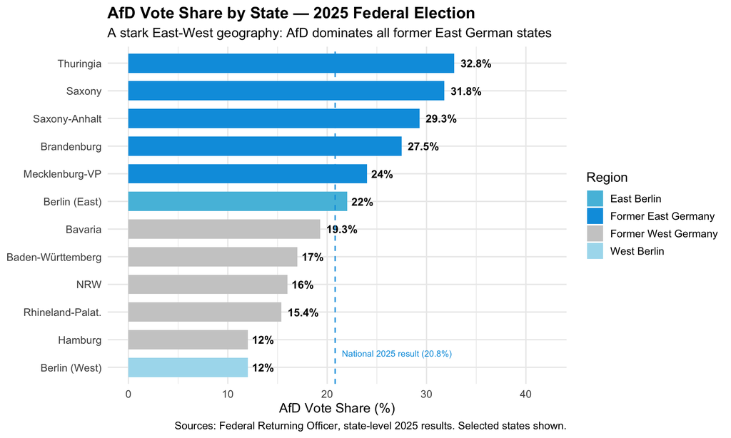

```r
east_west <- tibble(
  State   = c("Thuringia", "Saxony", "Saxony-Anhalt", "Brandenburg", "Mecklenburg-VP",
               "Berlin (East)", "Berlin (West)", "Bavaria", "Baden-Württemberg",
               "NRW", "Rhineland-Palat.", "Hamburg"),
  AfD_pct = c(32.8, 31.8, 29.3, 27.5, 24.0, 22.0, 12.0, 19.3, 17.0, 16.0, 15.4, 12.0),
  Region  = c(rep("Former East Germany", 5),
               "East Berlin", "West Berlin",
               rep("Former West Germany", 5))
)

p_ew <- east_west %>%
  mutate(State = fct_reorder(State, AfD_pct)) %>%
  ggplot(aes(x = State, y = AfD_pct, fill = Region)) +
  geom_col(width = 0.7) +
  geom_text(aes(label = paste0(AfD_pct, "%")), hjust = -0.2, size = 3.8, fontface = "bold") +
  coord_flip(ylim = c(0, 42)) +
  geom_hline(yintercept = 20.8, linetype = "dashed", colour = "#009EE0") +
  annotate("text", x = 1.5, y = 21.5, label = "National 2025 result (20.8%)",
           colour = "#009EE0", size = 3, hjust = 0) +
  scale_fill_manual(values = c(
    "Former East Germany" = "#009EE0",
    "East Berlin"         = "#55BEDE",
    "West Berlin"         = "#AADDEE",
    "Former West Germany" = "#CCCCCC"
  )) +
  labs(
    title    = "AfD Vote Share by State — 2025 Federal Election",
    subtitle = "A stark East-West geography: AfD dominates all former East German states",
    x        = NULL,
    y        = "AfD Vote Share (%)",
    fill     = "Region",
    caption  = "Sources: Federal Returning Officer, state-level 2025 results. Selected states shown."
  ) +
  theme_minimal(base_size = 13) +
  theme(
    plot.title = element_text(face = "bold"),
    legend.position = "right"
  )

print(p_ew)
```

**The East–West chasm is structurally significant.** The AfD secured all five former East German states in 2025, winning most direct constituencies there. In Saxony-Anhalt, current polling (Infratest dimap, Sep 2025) places the AfD at 39% — 12 points ahead of the CDU. In the West, the AfD typically polls 15–21%, well below its eastern strongholds. This geographic concentration has two consequences: it makes the Brandmauer harder to maintain in eastern state parliaments, and it suggests the AfD’s national ceiling is partly an artifact of its relative weakness in the more populous West.

## 3.3 Is the AfD a Protest Party or a Structural Force?

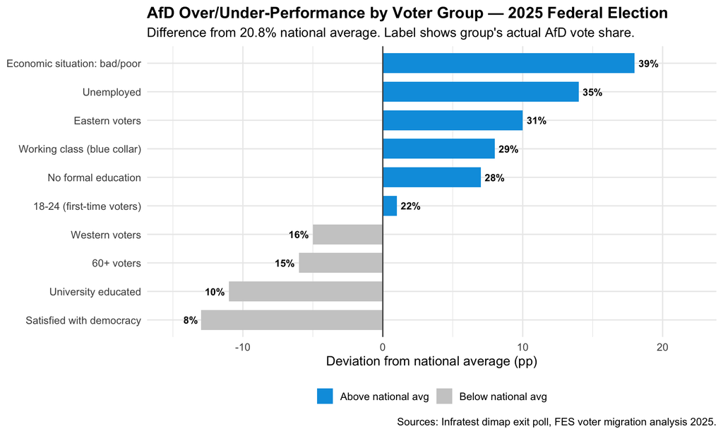

```r
# AfD voter sociology — cross-tabulation from 2025 Infratest dimap exit poll + FES analysis
voter_groups <- tibble(
  Group         = c("Working class (blue collar)", "Unemployed", "No formal education",
                     "Economic situation: bad/poor", "Eastern voters",
                     "18-24 (first-time voters)", "60+ voters",
                     "University educated", "Western voters", "Satisfied with democracy"),
  AfD_share     = c(29, 35, 28, 39, 31, 22, 15, 10, 16, 8),
  National_avg  = c(21, 21, 21, 21, 21, 21, 21, 21, 21, 21),
  Direction     = c("Over", "Over", "Over", "Over", "Over",
                     "Over", "Under", "Under", "Under", "Under")
)

p_voters <- voter_groups %>%
  mutate(
    Group = fct_reorder(Group, AfD_share),
    diff  = AfD_share - National_avg
  ) %>%
  ggplot(aes(x = Group, y = diff, fill = Direction)) +
  geom_col(width = 0.7) +
  geom_hline(yintercept = 0, colour = "grey30") +
  coord_flip() +
  geom_text(aes(label = paste0(AfD_share, "%")),
            hjust = ifelse(voter_groups$Direction == "Over", -0.2, 1.2),
            size = 3.5, fontface = "bold") +
  scale_fill_manual(values = c("Over" = "#009EE0", "Under" = "#CCCCCC"),
                    labels = c("Over" = "Above national avg", "Under" = "Below national avg")) +
  scale_y_continuous(limits = c(-15, 22)) +
  labs(
    title    = "AfD Over/Under-Performance by Voter Group — 2025 Federal Election",
    subtitle = "Difference from 20.8% national average. Label shows group's actual AfD vote share.",
    x        = NULL,
    y        = "Deviation from national average (pp)",
    fill     = NULL,
    caption  = "Sources: Infratest dimap exit poll, FES voter migration analysis 2025."
  ) +
  theme_minimal(base_size = 13) +
  theme(plot.title = element_text(face = "bold"), legend.position = "bottom")

print(p_voters)
```

The AfD’s sociology is critical to the ceiling question. Its over-performance among the economically marginalised, the unemployed, and eastern voters mirrors a structural realignment — not just protest voting. When the party polls **39% among those who rate their economic situation as poor**, that is not a fleeting anti-government reaction; it is a durable social coalition. The risk for mainstream parties is that economic improvement alone may not be sufficient to erode this support, because much AfD voting is about cultural and identity concerns as well as economic grievance.

# 4 The Brandmauer (Firewall): Strength, Cracks & Scenarios

## 4.1 The Firewall’s Architecture

```r
brandmauer <- tibble(
  Level       = c("Federal coalition", "Federal legislative votes",
                   "State-level coalition", "State minority government",
                   "Local/municipal cooperation"),
  Status      = c("Holds — CDU/CSU refuses coalition with AfD",
                   "BREACHED — CDU/FDP relied on AfD votes (Jan 29 2025) to pass migration motion",
                   "Holds formally — no CDU-AfD coalition in any Länder",
                   "Under pressure — Saxony minority CDU govt may need case-by-case AfD support post-2026",
                   "Substantially eroded — CDU cooperates with AfD on 38% of direct AfD motions"),
  Risk        = c("Low (2025-2028)", "Already occurred — precedent set",
                   "High in Saxony-Anhalt after Sep 2026 (AfD at 39%)",
                   "Likely in east German states 2026-2028",
                   "Ongoing — common in Saxony, Saxony-Anhalt, Thuringia"),
  Colour_flag = c("green", "red", "orange", "orange", "red")
)

brandmauer %>%
  select(Level, Status, Risk) %>%
  kable(
    caption = "Brandmauer Status by Political Level (March 2026)",
    col.names = c("Level", "Current Status", "Risk Assessment"),
    align = "lll"
  ) %>%
  kable_styling(bootstrap_options = c("striped", "hover"), full_width = TRUE) %>%
  row_spec(2, bold = TRUE, color = "white", background = "#cc3333") %>%
  row_spec(5, bold = FALSE, color = "white", background = "#cc3333") %>%
  row_spec(3, bold = FALSE, color = "black", background = "#FFCC66") %>%
  row_spec(4, bold = FALSE, color = "black", background = "#FFCC66") %>%
  footnote(
    general = "Red = already breached or substantially eroded. Orange = under pressure. Green = holding.
    The January 29, 2025 vote in which CDU/FDP passed a migration motion using AfD votes was the first breach
    of the cordon sanitaire at the federal level since 1945. Political scientist Isabelle Borucki called it
    'a historic moment when the so-called Brandmauer fell'.
    Source: WZB empirical study (2025), Wikipedia Firewall article, Jacobin Germany analysis.",
    general_title = "Note: "
  )
```

Brandmauer Status by Political Level (March 2026)

| Level | Current Status | Risk Assessment |
| --- | --- | --- |
| Federal coalition | Holds — CDU/CSU refuses coalition with AfD | Low (2025-2028) |
| Federal legislative votes | BREACHED — CDU/FDP relied on AfD votes (Jan 29 2025) to pass migration motion | Already occurred — precedent set |
| State-level coalition | Holds formally — no CDU-AfD coalition in any Länder | High in Saxony-Anhalt after Sep 2026 (AfD at 39%) |
| State minority government | Under pressure — Saxony minority CDU govt may need case-by-case AfD support post-2026 | Likely in east German states 2026-2028 |
| Local/municipal cooperation | Substantially eroded — CDU cooperates with AfD on 38% of direct AfD motions | Ongoing — common in Saxony, Saxony-Anhalt, Thuringia |

Note:  
Red = already breached or substantially eroded. Orange = under pressure. Green = holding. The January 29, 2025 vote in which CDU/FDP passed a migration motion using AfD votes was the first breach of the cordon sanitaire at the federal level since 1945. Political scientist Isabelle Borucki called it ‘a historic moment when the so-called Brandmauer fell’. Source: WZB empirical study (2025), Wikipedia Firewall article, Jacobin Germany analysis.

## 4.2 Two Firewalls: A Conceptual Framework

The WZB (Berlin Social Science Centre) distinguishes between **two distinct firewalls**:

- **Firewall 1 (indirect cooperation):** Mainstream parties pass their own motions using AfD votes as a de facto majority. This was **breached** on January 29, 2025 at the federal level, and is routinely breached at municipal level in eastern Germany.
- **Firewall 2 (direct cooperation):** Mainstream parties vote *in favour* of AfD motions or candidates. At the federal level this has not yet happened. At local level in eastern Germany, CDU representatives support AfD motions in approximately 38% of cases.

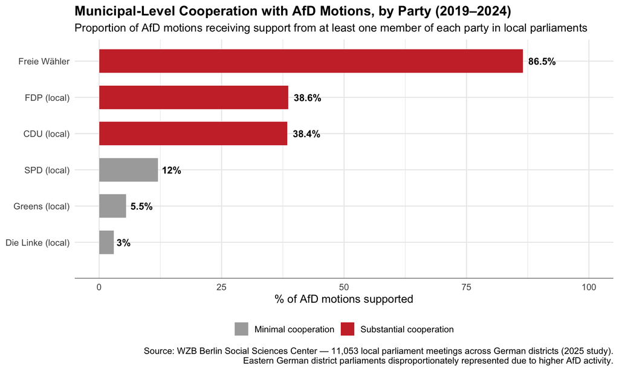

```r
# Municipal-level cooperation data: WZB study (2025) — 11,053 local meetings analysed
municipal_cooperation <- tibble(
  Party         = c("Freie Wähler", "FDP (local)", "CDU (local)", "SPD (local)",
                     "Greens (local)", "Die Linke (local)"),
  AfD_support_pct = c(86.5, 38.6, 38.4, 12.0, 5.5, 3.0),
  Sample_note   = c("Free Voters — frequently ally",
                     "FDP local branches; same as federal breach Jan 2025",
                     "CDU local branches; most significant given CDU size",
                     "SPD local; mostly in transport/budget votes",
                     "Greens local — rare exceptions only",
                     "Die Linke — maintains firewall most consistently")
)

p_muni <- municipal_cooperation %>%
  mutate(Party = fct_reorder(Party, AfD_support_pct)) %>%
  ggplot(aes(x = Party, y = AfD_support_pct,
             fill = AfD_support_pct > 30)) +
  geom_col(width = 0.65) +
  geom_text(aes(label = paste0(AfD_support_pct, "%")),
            hjust = -0.2, size = 4, fontface = "bold") +
  coord_flip(ylim = c(0, 100)) +
  geom_vline(xintercept = 0, colour = "grey30") +
  scale_fill_manual(values = c("FALSE" = "#AAAAAA", "TRUE" = "#cc3333"),
                    labels = c("FALSE" = "Minimal cooperation", "TRUE" = "Substantial cooperation")) +
  labs(
    title    = "Municipal-Level Cooperation with AfD Motions, by Party (2019–2024)",
    subtitle = "Proportion of AfD motions receiving support from at least one member of each party in local parliaments",
    x        = NULL,
    y        = "% of AfD motions supported",
    fill     = NULL,
    caption  = "Source: WZB Berlin Social Sciences Center — 11,053 local parliament meetings across German districts (2025 study).\nEastern German district parliaments disproportionately represented due to higher AfD activity."
  ) +
  theme_minimal(base_size = 13) +
  theme(plot.title = element_text(face = "bold"), legend.position = "bottom")

print(p_muni)
```

## 4.3 Can the AfD Force a Governance Crisis?

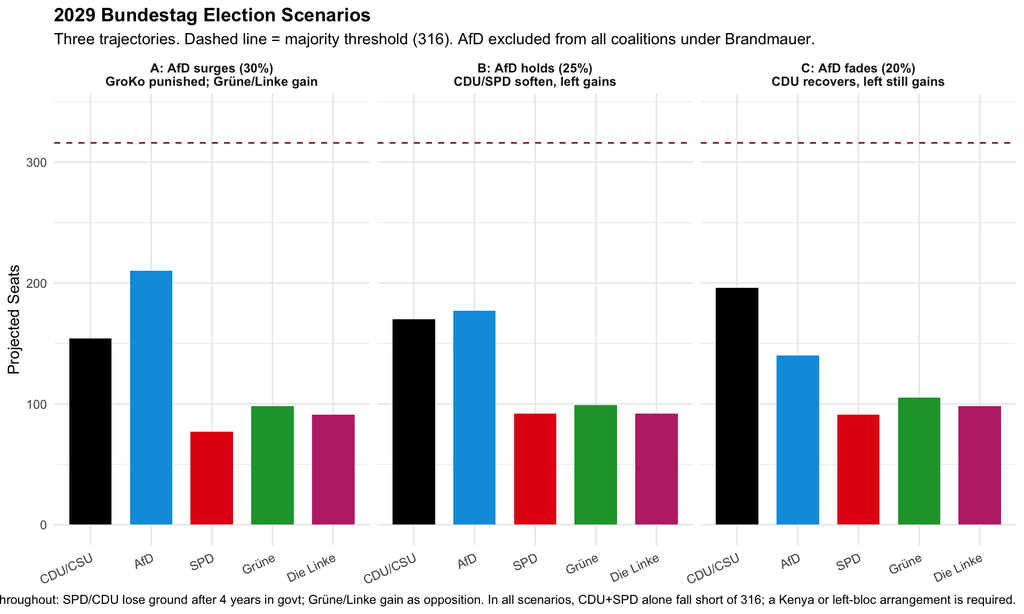

```r
# Seat arithmetic for 2029 scenarios
scenarios_2029_de <- tibble(
  Party     = rep(c("CDU/CSU", "AfD", "SPD", "Grüne", "Die Linke"), 3),
  Scenario  = rep(c("A: AfD surges (30%)\nGroKo punished; Grüne/Linke gain",
                     "B: AfD holds (25%)\nCDU/SPD soften, left gains",
                     "C: AfD fades (20%)\nCDU recovers, left still gains"), each = 5),
  Vote_share = c(
    # A: AfD surges to 30%; GroKo incumbency punishes CDU (22%) and SPD (11%); Grüne/Linke gain as opposition
    22, 30, 11, 14, 13,
    # B: AfD holds ~25%; CDU and SPD both shed 2pp to Grüne/Linke after 4 yrs in govt
    24, 25, 13, 14, 13,
    # C: AfD falls to 20%; CDU recovers, SPD still softens to Grüne/Linke
    28, 20, 13, 15, 14
  ),
  Proj_seats = c(
    # A: eligible 90% of vote -> Sainte-Laguë on 630 seats
    154, 210, 77, 98, 91,   # A
    170, 177, 92, 99, 92,   # B
    196, 140, 91, 105, 98   # C
  )
)

p_scen_de <- scenarios_2029_de %>%
  mutate(Party = factor(Party, levels = c("CDU/CSU", "AfD", "SPD", "Grüne", "Die Linke"))) %>%
  ggplot(aes(x = Party, y = Proj_seats, fill = Party)) +
  geom_col(width = 0.7) +
  geom_hline(yintercept = 316, linetype = "dashed", colour = "darkred") +
  facet_wrap(~Scenario) +
  scale_fill_manual(values = c(
    "CDU/CSU"   = "#000000",
    "AfD"       = "#009EE0",
    "SPD"       = "#E3000F",
    "Grüne"     = "#1AA037",
    "Die Linke" = "#BE3075"
  )) +
  scale_y_continuous(limits = c(0, 340)) +
  labs(
    title    = "2029 Bundestag Election Scenarios",
    subtitle = "Three trajectories. Dashed line = majority threshold (316). AfD excluded from all coalitions under Brandmauer.",
    x        = NULL, y = "Projected Seats",
    caption  = "GroKo incumbency drag assumed throughout: SPD/CDU lose ground after 4 years in govt; Grüne/Linke gain as opposition. In all scenarios, CDU+SPD alone fall short of 316; a Kenya or left-bloc arrangement is required."
  ) +
  theme_minimal(base_size = 11) +
  theme(
    plot.title      = element_text(face = "bold"),
    legend.position = "none",
    axis.text.x     = element_text(angle = 25, hjust = 1),
    strip.text      = element_text(face = "bold", size = 9)
  )

print(p_scen_de)
```

**The extreme tail risk: AfD + Die Linke jointly exceed 50%.** This scenario is currently remote — at March 2026 polling the two parties together hold roughly 36% (AfD ~25%, Linke ~11%), far short of a Bundestag majority. But it is not entirely inconceivable on a long-run trajectory where GroKo failure drives SPD voters further left and AfD consolidation continues. If AfD and Die Linke were together to cross the 316-seat threshold — say AfD at 33% and Linke at 18% after a prolonged governance crisis — **the Bundestag would face genuine deadlock**: no government could be formed without one of them, yet all mainstream parties refuse coalition with both. Under the Basic Law, if no Chancellor can be elected by absolute majority after repeated votes, the Federal President can either appoint a minority Chancellor or dissolve the Bundestag and call a snap election (Art. 63 IV GG). In practice, Die Linke folding to support a CDU minority Chancellor to avoid fresh elections is more likely than true deadlock — but the constitutional machinery would be tested as it has not been since the Federal Republic’s founding. The scenario is assigned low probability but is included here because its structural trigger (GroKo failure → SPD collapse → Linke surge alongside AfD consolidation) is precisely the dynamic the current GroKo risks setting in motion.